# Project 2: Classifying NFL players and predicting their longevity

Group 4, Section 11

2023-12-12

```r
nfl_data_clean <- read.csv("../dataset/nfl_players_clean.csv")
nfl_data_clean$position_group <- as.factor(nfl_data_clean$position_group)
```

# Introduction

## Part 1 Recap

In Part 1 of this project, we introduced the NFL dataset which contained data about the physical attributes, position of play, and years of current and retired NFL players.  
After cleaning the data, we were left with 7098 observations of 8 variables.  
The distribution of these players into the 9 position groups is shown below.

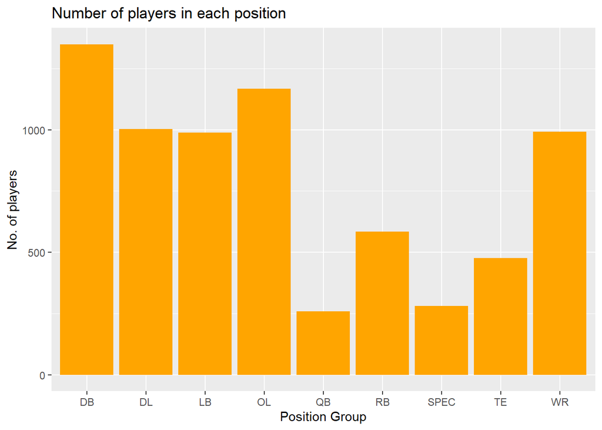

```r
ggplot(nfl_data_clean, aes(x = position_group)) +
  geom_bar(fill = "orange") +
  labs(title = "Number of players in each position", x="Position Group", y="No. of players")
```

After performing EDA on each variable, we performed ANOVA tests on our variables of interest: `height`, `weight` and `years_of_experience` in relation `position_group`.

```r
anova_model_wt <- aov(weight~position_group, nfl_data_clean)
xkabledply(anova_model_wt, title="ANOVA test Weight vs Position Group")
```

ANOVA test Weight vs Position Group

|  | Df | Sum Sq | Mean Sq | F value | Pr(>F) |
| --- | --- | --- | --- | --- | --- |
| position_group | 8 | 13320702 | 1665088 | 6143 | 0 |
| Residuals | 7089 | 1921540 | 271 | NA | NA |

p-value for this ANOVA test is 0,implying the `weight` is dependent on position groups.

```r
anova_model_ht <- aov(height~position_group, nfl_data_clean)
xkabledply(anova_model_ht, title="ANOVA test Height vs Position Group")
```

ANOVA test Height vs Position Group

|  | Df | Sum Sq | Mean Sq | F value | Pr(>F) |
| --- | --- | --- | --- | --- | --- |
| position_group | 8 | 27132 | 3391.54 | 1105 | 0 |
| Residuals | 7089 | 21767 | 3.07 | NA | NA |

p-value for this ANOVA test is 0,implying the `height` is dependent on position groups.

```r
pos_yoe <- aov(years_of_experience ~ position_group, nfl_data_clean)
xkabledply(pos_yoe, title = "ANOVA test YOE vs Position Group")
```

ANOVA test YOE vs Position Group

|  | Df | Sum Sq | Mean Sq | F value | Pr(>F) |
| --- | --- | --- | --- | --- | --- |
| position_group | 8 | 1814 | 226.7 | 19.2 | 0 |
| Residuals | 7089 | 83864 | 11.8 | NA | NA |

p-value for this ANOVA test is 0,implying the `years_of_experience` is dependent on position groups.

**After performing ANOVA tests, our suspicion that the height, weight and years of experience for an NFL player are dependent on their position group.**

## Part 2 Agenda

After performing EDA and Hypothesis tests to confirm that height, weight and YOE depend on a player’s position group, we are now interested to model the following relationships:

- Classifying NFL players into different position groups based on their height and weight.
- Predicting NFL player’s YOE based on height, weight and position group.

To perform these modelling tasks, we follow these steps:

1. Finding the correlations between the variables of interest: `height`, `weight`, `years_of_experience` and `position_group`.
2. Building and evaluating classification models to classify players into `position_group` based on `height` and `weight`. Since this is a multiclass classification, we will use multinomial logistic regression and k-nearest neighbors classifiers.
3. Building and evaluating regression models to predict the `years_of_experience` of a player based on `height`, `weight` and `position_group`. For this we will use linear regression and random forest regression models.

# Finding Correlation among Variables

## Correlating the numeric variables

First, we find the correlation between the three numerical variables of interest: `height`, `weight`, and `years_of_experience`.

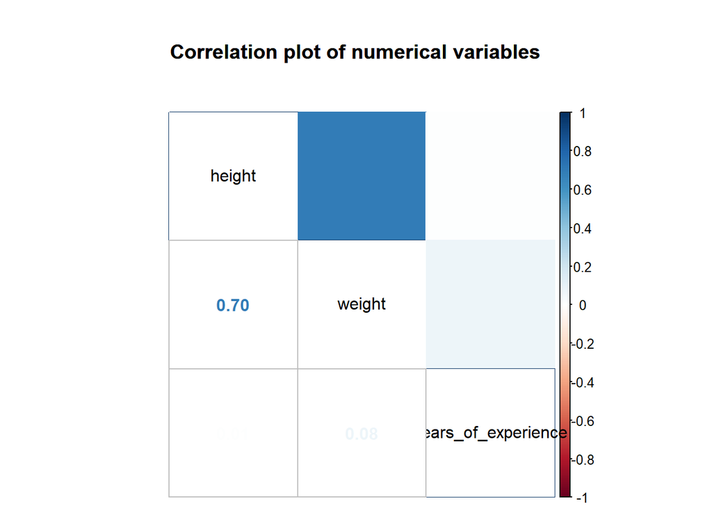

```r
correlation_data_years <- cor(nfl_data_clean[, c("height", "weight", "years_of_experience")])
corrplot.mixed(correlation_data_years,upper="color", lower="number", tl.col = "black", tl.srt = 45, mar=c(0,0,5,0), main = "Correlation plot of numerical variables")
```

## Group-wise correlation of numeric variables

As we saw in part 1, the distributions of `height`, `weight` and `years_of_experience` vary by position group. Hence we will study the correlation of these variables for each position group.

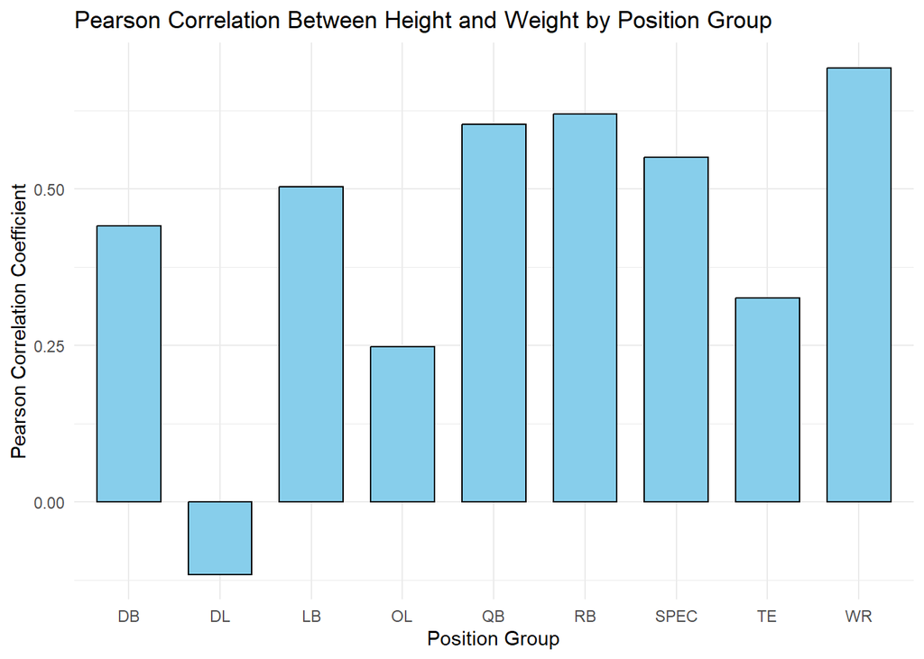

```r
# Get unique position groups
position_groups <- unique(nfl_data_clean$position_group)

correlation_results <- data.frame(Position_Group = character(),
                                  Pearson_Correlation_Height_Weight = numeric(),
                                  Pearson_Correlation_Height_Years = numeric(),
                                  Pearson_Correlation_Weight_Years = numeric(),
                                  stringsAsFactors = FALSE)

# Loop through each position group
for (group in position_groups) {
  # Subset data for the current position group
  data_subset <- subset(nfl_data_clean, position_group == group)

  # Calculate Pearson correlation coefficients
  correlation_height_weight <- cor(data_subset$height, data_subset$weight, method = "pearson")
  correlation_height_years <- cor(data_subset$height, data_subset$years_of_experience, method = "pearson")
  correlation_weight_years <- cor(data_subset$weight, data_subset$years_of_experience, method = "pearson")

  # Add results to the data frame
  correlation_results <- rbind(correlation_results,
                               data.frame(Position_Group = group,
                                          Pearson_Correlation_Height_Weight = correlation_height_weight,
                                          Pearson_Correlation_Height_Years = correlation_height_years,
                                          Pearson_Correlation_Weight_Years = correlation_weight_years))
}

plot1 <- ggplot(correlation_results, aes(x = Position_Group, y = Pearson_Correlation_Height_Weight)) +
  geom_bar(stat = "identity", fill = "skyblue", color = "black", width = 0.7) +
  labs(title = "Pearson Correlation Between Height and Weight by Position Group",
       x = "Position Group", y = "Pearson Correlation Coefficient") + theme_minimal()

plot2 <- ggplot(correlation_results, aes(x = Position_Group, y = Pearson_Correlation_Height_Years)) +
  geom_bar(stat = "identity", fill = "skyblue", color = "black", width = 0.7) +
  labs(title = "Pearson Correlation Between Height and YOE by Position Group",
       x = "Position Group", y = "Pearson Correlation Coefficient") + theme_minimal()

plot3 <- ggplot(correlation_results, aes(x = Position_Group, y = Pearson_Correlation_Weight_Years)) +
  geom_bar(stat = "identity", fill = "skyblue", color = "black", width = 0.7) +
  labs(title = "Pearson Correlation Between Weight and YOE by Position Group",
       x = "Position Group", y = "Correlation Coefficient") + theme_minimal()

plot1
```

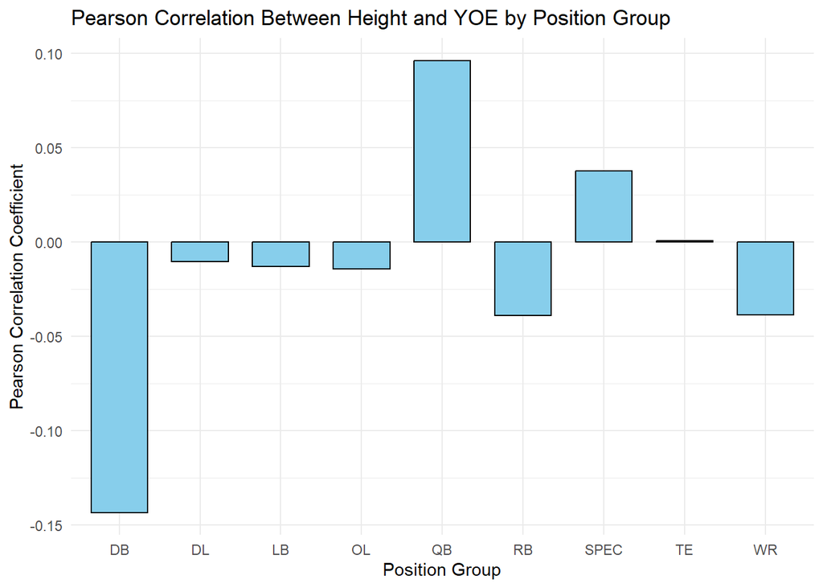

```r
plot2
```

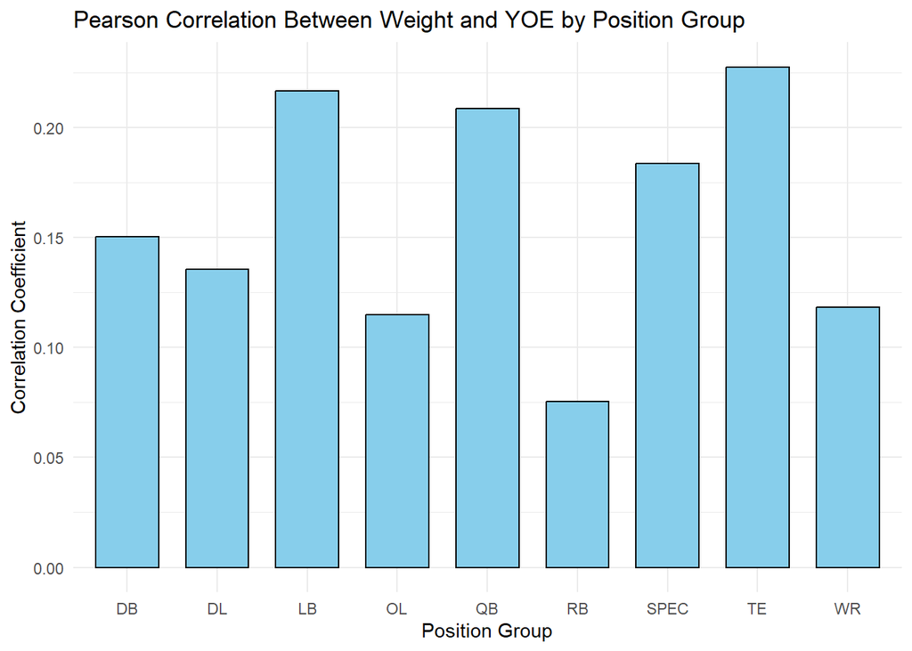

```r
plot3
```

# Classifying NFL players into position groups

The first modelling task is to classify the NFL players in the dataset into position groups based on their height and weight distribution. For this task we employ multinomial logistic regression and k-nearest neighbors models and compare their results.

## Multinomial LR

Multinomial LR model is used when the target variable has multiple categories. In our case, the target variable `position_group` has 9 categories. The multinomial LR model predicts the log-odds ratio of an observation belonging to each class.

```r
fit_basic <- multinom(position_group ~ height + weight, data = nfl_data_clean)
```

After fitting the model, lets take a look at the coefficients in the log-odds scale.

```r
coef(fit_basic)
```

```
##      (Intercept)  height  weight
## DL         -66.1 -0.1539  0.3293
## LB         -20.1 -0.3672  0.2141
## OL        -129.5  0.4552  0.3862
## QB         -56.0  0.5130  0.0793
## RB          42.9 -1.0995  0.1691
## SPEC       -19.9  0.0186  0.0826
## TE         -97.0  0.6434  0.2141
## WR         -16.4  0.2570 -0.0127
```

We see that the model is actually 8 different LR equations corresponding to 8 classes. The class “DB” is not present since that is considered as the base class and the other equations are calculated with respect to the base class. Each equation gives us the log-odds ratio of an observation belonging to the corresponding class.

Next, we obtain the predictions for the dataset from the model. Each prediction is an array with 9 values where each value corresponds to the probability of the observation belonging to that class. We then use th `argmax()` function to get the index of the class with highest probability. After obtaining the prediction values, we map it back to the factor levels in `position_group`.

```r
pp <- fitted(fit_basic)
prediction <- argmax(pp)

prediction[prediction == 1] = "DB"
prediction[prediction == 2] = "DL"
prediction[prediction == 3] = "LB"
prediction[prediction == 4] = "OL"
prediction[prediction == 5] = "QB"
prediction[prediction == 6] = "RB"
prediction[prediction == 7] = "SPEC"
prediction[prediction == 8] = "TE"
prediction[prediction == 9] = "WR"

nfl_data_clean$prediction <- factor(prediction, levels = c("DB", "DL", "LB", "OL", "QB", "RB", "SPEC", "TE", "WR"))
print("Summary of predictions: ")
```

```
## [1] "Summary of predictions: "
```

```r
summary(nfl_data_clean$prediction)
```

```
##   DB   DL   LB   OL   QB   RB SPEC   TE   WR
## 1959  909 1380 1202  133  493    0  379  643
```

### MLR : Confusion Matrix and Model evaluation

To evaluate the overall accuracy and class-wise accuracy of the model, we construct the confusion matrix.

```r
cm <- confusionMatrix(nfl_data_clean$position_group, nfl_data_clean$prediction)
xkabledply(cm$table)
```

Table

|  | DB | DL | LB | OL | QB | RB | SPEC | TE | WR |
| --- | --- | --- | --- | --- | --- | --- | --- | --- | --- |
| DB | 1040 | 1 | 14 | 0 | 6 | 74 | 0 | 0 | 214 |
| DL | 0 | 567 | 120 | 257 | 1 | 0 | 0 | 56 | 1 |
| LB | 31 | 74 | 733 | 3 | 10 | 66 | 0 | 56 | 16 |
| OL | 0 | 226 | 0 | 940 | 0 | 0 | 0 | 2 | 0 |
| QB | 64 | 0 | 61 | 0 | 48 | 4 | 0 | 23 | 58 |
| RB | 134 | 4 | 141 | 1 | 1 | 301 | 0 | 0 | 2 |
| SPEC | 96 | 2 | 83 | 0 | 10 | 18 | 0 | 14 | 57 |
| TE | 0 | 35 | 202 | 1 | 17 | 0 | 0 | 220 | 2 |
| WR | 594 | 0 | 26 | 0 | 40 | 30 | 0 | 8 | 293 |

From the confusion matrix, we can get the overall accuracy as : 0.584.  
However, since this is a multiclass problem, we look at the statistics for each class. We mainly focus on the balanced accuracy for each class which is the Arithmetic Mean of Sensitivity and Specificity. Balanced accuracy tells us how good the model is in predicting if an observation belongs inside or outside of a class.

```r
xkabledply(cm$byClass[,c('Sensitivity', 'Specificity', 'Balanced Accuracy')])
```

Table

|  | Sensitivity | Specificity | Balanced Accuracy |
| --- | --- | --- | --- |
| Class: DB | 0.531 | 0.940 | 0.735 |
| Class: DL | 0.624 | 0.930 | 0.777 |
| Class: LB | 0.531 | 0.955 | 0.743 |
| Class: OL | 0.782 | 0.961 | 0.872 |
| Class: QB | 0.361 | 0.970 | 0.665 |
| Class: RB | 0.611 | 0.957 | 0.784 |
| Class: SPEC | NA | 0.961 | NA |
| Class: TE | 0.581 | 0.962 | 0.771 |
| Class: WR | 0.456 | 0.892 | 0.674 |

## K - nearest neighbors classifier

The KNN Classifier model predicts the class of an observation based on the class of it’s nearest `k` neighbors. `k` is a hyperparameter of this model and is used to set how many neighbors each observation should be compared with. The distance between data points is calculated for each of the feature columns. After determining the `k` nearest neighbors of an observation, the class of the observation is predicted based on the class to which majority of its neighbors belong.  
In our case, we only use two features `height` and `weight` to determine the `position_group` of an observation. In the two feature case, it is easy to visualize KNN classifier as dividing up the feature space in `c` different regions where `c` is the number of classes.

First, we split the data into train and test sets in an 80:20 ratio.

```r
data <- nfl_data_clean[c("weight", "height", "position_group")]

train_index <- createDataPartition(data$position_group, times=1, p=0.8, list=F)

train_data <- data[train_index,]
test_data <- data[-train_index,]
```

There are 5683 observations in the training set, and 1415 observations in the test set.  
Next, we normalize the data by centering it around the mean and scaling it by the standard deviation. We perform this operation on both test and train sets. However, we use the mean and standard deviation of only the training set.

```r
preProcValues <- preProcess(train_data, method=c("center", "scale"))
train_data <- predict(preProcValues, train_data)
test_data <- predict(preProcValues, test_data)
```

Centering and scaling the data ensures that both variables are distributed along a similar scale and it becomes easier to calculate distances. Otherwise, the variable on the higher scale will have more impact on the distances than the other. In our case, `weight` would have a higher impact on distances than `height`.  
Now, we will build the model. First, we try out different values of `k` to determine the best one. Lower values of `k` increases the variance of the model and might have a tendency to overfit. Whereas higher values of `k` compromise on accuracy.

```r
knn_model <- train(position_group~., data=train_data, method="knn",
                    trControl=trainControl(method="cv"),
                    tuneGrid=data.frame(k=c(20,40,50,100, 200, 250)))
```

After tuning the model, we find that the best value of `k` is 100. Next we build and train the model with this value of `k`.

```r
best_knn <- knn3(position_group ~., data=train_data, k=knn_model$bestTune$k)

train_preds <- predict(best_knn, train_data, type="class")
cm1 <- confusionMatrix(train_preds, train_data$position_group)

xkabledply(cm1$table)
```

Table

|  | DB | DL | LB | OL | QB | RB | SPEC | TE | WR |
| --- | --- | --- | --- | --- | --- | --- | --- | --- | --- |
| DB | 936 | 0 | 15 | 0 | 45 | 134 | 85 | 0 | 484 |
| DL | 1 | 397 | 42 | 78 | 0 | 1 | 1 | 13 | 0 |
| LB | 16 | 86 | 582 | 1 | 36 | 127 | 60 | 91 | 18 |
| OL | 0 | 241 | 1 | 854 | 0 | 1 | 0 | 0 | 0 |
| QB | 6 | 0 | 7 | 0 | 33 | 0 | 5 | 10 | 15 |
| RB | 32 | 0 | 24 | 0 | 3 | 193 | 11 | 0 | 19 |
| SPEC | 0 | 0 | 0 | 0 | 0 | 0 | 0 | 0 | 0 |
| TE | 0 | 77 | 95 | 2 | 25 | 1 | 21 | 260 | 10 |
| WR | 89 | 1 | 26 | 0 | 65 | 11 | 41 | 8 | 247 |

We get an overall training accuracy of 0.616.

### KNN : Confusion Matrix and Model Evaluation

Lets see how it performs on the test set.

```r
preds <- predict(best_knn, test_data, type="class")
cm2 <- confusionMatrix(preds, test_data$position_group)

xkabledply(cm2$table)
```

Table

|  | DB | DL | LB | OL | QB | RB | SPEC | TE | WR |
| --- | --- | --- | --- | --- | --- | --- | --- | --- | --- |
| DB | 237 | 0 | 3 | 0 | 8 | 29 | 24 | 0 | 134 |
| DL | 0 | 96 | 11 | 22 | 0 | 1 | 0 | 3 | 0 |
| LB | 2 | 22 | 137 | 1 | 9 | 39 | 11 | 23 | 4 |
| OL | 0 | 59 | 0 | 210 | 0 | 0 | 0 | 1 | 0 |
| QB | 0 | 0 | 3 | 0 | 2 | 0 | 2 | 0 | 5 |
| RB | 10 | 0 | 6 | 0 | 1 | 45 | 2 | 0 | 2 |
| SPEC | 0 | 0 | 0 | 0 | 0 | 0 | 0 | 0 | 0 |
| TE | 0 | 22 | 28 | 0 | 10 | 0 | 5 | 65 | 0 |
| WR | 20 | 1 | 9 | 0 | 21 | 2 | 12 | 3 | 53 |

```r
xkabledply(cm2$byClass[,c('Sensitivity', 'Specificity', 'Balanced Accuracy')])
```

Table

|  | Sensitivity | Specificity | Balanced Accuracy |
| --- | --- | --- | --- |
| Class: DB | 0.8810 | 0.827 | 0.854 |
| Class: DL | 0.4800 | 0.970 | 0.725 |
| Class: LB | 0.6954 | 0.909 | 0.802 |
| Class: OL | 0.9013 | 0.949 | 0.925 |
| Class: QB | 0.0392 | 0.993 | 0.516 |
| Class: RB | 0.3879 | 0.984 | 0.686 |
| Class: SPEC | 0.0000 | 1.000 | 0.500 |
| Class: TE | 0.6842 | 0.951 | 0.818 |
| Class: WR | 0.2677 | 0.944 | 0.606 |

## Classification model conclusions

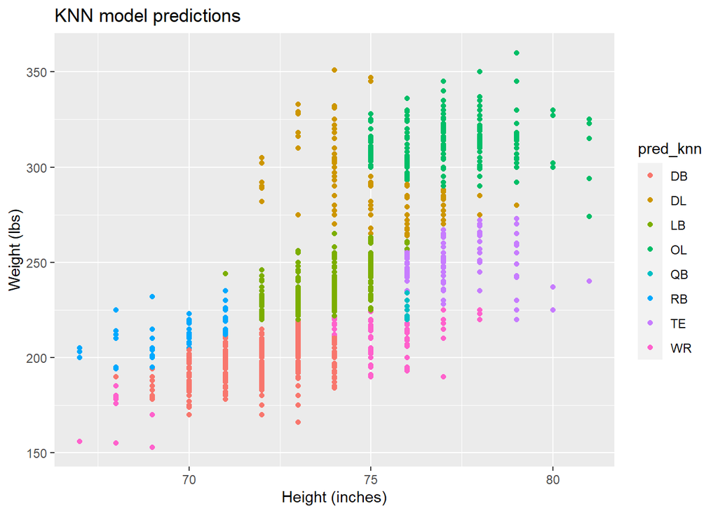

```r
test_data_clean <- data[-train_index,]
test_data_clean$pred_knn <- preds
plt <- ggplot(data=test_data_clean) + geom_point(mapping = aes(x=height, y=weight, col=pred_knn)) +
  labs(title = "KNN model predictions") + labs(x="Height (inches)", y="Weight (lbs)")
plt
```

### Investigating the SPEC class

The “SPEC” or Special position group in NFL refers to a group of players meant for playing very specific roles in set-piece situations such as kicker, punter etc. SPEC players do not have any characteristic desirable physical attributes since it varies by their specific role. Moreover, the height and weight distribution of players in the SPEC class overlaps with other classes. This fact, combined with the presence of very few observations from SPEC class in the dataset means that neither models performed well in identifying the SPEC class.

# Predicting years of experience

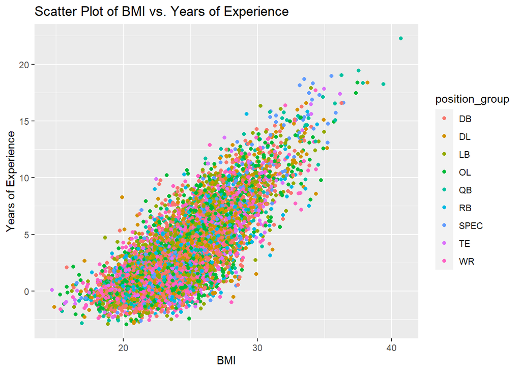

```r
nfl_clean <- read.csv("../dataset/nfl_players_clean_bmi.csv")
nfl_clean$position_group <- as.factor(nfl_clean$position_group)

# Create a scatter plot with points colored by position_group
ggplot(nfl_clean, aes(x = BMI, y = years_of_experience, color = position_group)) +
  geom_point() +
  ggtitle("Scatter Plot of BMI vs. Years of Experience") +
  xlab("BMI") +
  ylab("Years of Experience")
```

After this, we built the Linear Model for Years of Experience using BMI and Position Group.

```r
set.seed(123)

# Split the dataset into training (80%) and testing (20%) sets
train_indices <- sample(1:nrow(nfl_clean), 0.8 * nrow(nfl_clean))
train_data_ <- nfl_clean[train_indices, ]
test_data_ <- nfl_clean[-train_indices, ]

lm_model <- lm(years_of_experience ~ position_group + BMI, data = train_data_)

summary(lm_model)
```

```
##
## Call:
## lm(formula = years_of_experience ~ position_group + BMI, data = train_data_)
##
## Residuals:
##    Min     1Q Median     3Q    Max
## -7.428 -1.525 -0.081  1.422  8.612
##
## Coefficients:
##                     Estimate Std. Error t value Pr(>|t|)
## (Intercept)        -17.85588    0.23258  -76.77  < 2e-16 ***
## position_groupDL     0.19189    0.10361    1.85  0.06408 .
## position_groupLB     0.16578    0.10492    1.58  0.11417
## position_groupOL     0.11376    0.09922    1.15  0.25161
## position_groupQB     0.60728    0.16851    3.60  0.00032 ***
## position_groupRB    -0.13999    0.12281   -1.14  0.25438
## position_groupSPEC   0.51505    0.16334    3.15  0.00162 **
## position_groupTE    -0.07481    0.13240   -0.56  0.57210
## position_groupWR    -0.07324    0.10441   -0.70  0.48304
## BMI                  0.86833    0.00911   95.30  < 2e-16 ***
## ---
## Signif. codes:  0 '***' 0.001 '**' 0.01 '*' 0.05 '.' 0.1 ' ' 1
##
## Residual standard error: 2.22 on 5668 degrees of freedom
## Multiple R-squared:  0.621,  Adjusted R-squared:  0.621
## F-statistic: 1.03e+03 on 9 and 5668 DF,  p-value: <2e-16
```

Here’s the interpretation of the linear regression summary:

**This model suggests that position groups, especially QB and SPEC, along with BMI, significantly influence years of experience in the given context.**

```r
# Make predictions on the test set
predictions <- predict(lm_model, newdata = test_data_)

# Calculate RMSE
rmse <- sqrt(mean((predictions - test_data_$years_of_experience)^2))

# Print the RMSE
cat("Root Mean Squared Error (RMSE) - Linear Regression :", rmse, "\n")
```

```
## Root Mean Squared Error (RMSE) - Linear Regression : 2.22
```

In pursuit of modelling the dependent variable better, we wanted to try out one more model.So we employed the ensemble technique of Random Forest and re-modeled.

```r
# Train the Random Forest model
rf_model <- randomForest(
  years_of_experience ~ position_group + BMI,
  data = train_data_,
  ntree = 500,  # Number of trees in the forest
       # Number of variables randomly sampled as candidates at each split
  importance = TRUE
)

# Summary of the model
print(rf_model)
```

```
##
## Call:
##  randomForest(formula = years_of_experience ~ position_group +      BMI, data = train_data_, ntree = 500, importance = TRUE)
##                Type of random forest: regression
##                      Number of trees: 500
## No. of variables tried at each split: 1
##
##           Mean of squared residuals: 4.75
##                     % Var explained: 63.5
```

Here’s the interpretation of the random forest regression summary:

```r
# Make predictions on the test set
predictions_rf <- predict(rf_model, newdata = test_data_)

# Continue with the comparison and RMSE calculation as before
# comparison_rf <- data.frame(Actual = test_data_$years_of_experience, Predicted = predictions_rf)
# print(head(comparison_rf))

# Calculate RMSE
rmse_rf <- sqrt(mean((predictions_rf - test_data_$years_of_experience)^2))
cat("Root Mean Squared Error (RMSE) - Random Forest:", rmse_rf, "\n")
```

```
## Root Mean Squared Error (RMSE) - Random Forest: 2.17
```

Before concluding, we tweaked the random forest model with different parameters, like below i.e. changing the number of trees.

```r
# Train the Random Forest model
rf_model2 <- randomForest(
  years_of_experience ~ position_group + BMI,
  data = train_data_,
  ntree = 600,  # Number of trees in the forest
       # Number of variables randomly sampled as candidates at each split
  importance = TRUE
)

# Summary of the model
print(rf_model2)
```

```
##
## Call:
##  randomForest(formula = years_of_experience ~ position_group +      BMI, data = train_data_, ntree = 600, importance = TRUE)
##                Type of random forest: regression
##                      Number of trees: 600
## No. of variables tried at each split: 1
##
##           Mean of squared residuals: 4.76
##                     % Var explained: 63.4
```

```r
# Make predictions on the test set
predictions_rf2 <- predict(rf_model2, newdata = test_data_)

# Continue with the comparison and RMSE calculation as before
# comparison_rf <- data.frame(Actual = test_data_$years_of_experience, Predicted = predictions_rf)
# print(head(comparison_rf))

# Calculate RMSE
rmse_rf2 <- sqrt(mean((predictions_rf2 - test_data_$years_of_experience)^2))
cat("Root Mean Squared Error (RMSE) - Random Forest:", rmse_rf2, "\n")
```

```
## Root Mean Squared Error (RMSE) - Random Forest: 2.17
```

But doing that didn’t produce any significant difference as evident from the % variance explained and RMSE.

Comparison:

**In summary, the random forest model shows a marginally better predictive performance compared to the linear regression model, as evidenced by a slightly lower RMSE and a slightly higher percentage of variance explained.** **In a nutshell, the model kind of peaked at explaining ~64 % variability since there are more factors at play in determining the Years of Experience than just the BMI and Position of Play since real life is complicated and career lifespan of a player takes on a more nuanced approach rather than just a simple linear relationship.**

# Conclusion

NFL is a complex sport with multiple position groups, each with varied functions and styles of play. Although height and weight are key attributes for most positions, other attributes such as speed, vertical jump height play a vital role for some positions. Skill positions such as quarterback and special groups have other unique characteristics.  
NFL is a highly physical sport with the highest injury rate among sports. Players in positions such as offensive and defensive linemen, line backers, and defensive backs have a high chance of injury which ends up cutting their career. On the other hand, quarterbacks are a skill position who do not encounter much injury threats and have a longer career. However, like most other sports, having high muscle mass (which translates to a high BMI) substantially helps players avoid or recover from injury and prolong their careers.  
Keeping these caveats in mind, we can draw the following conclusions from our project:

1. As expected, we were able to find correlations between height, weight and position group of NFL players.
2. We were able to exploit these correlations and build models to classify players into position groups.
3. Classification models achieved a moderate overall accuracy and worked well on position groups with more players.
4. We exploited the correlation between height, weight, position group and YOE to build regression models.
5. The regression models performed decently with the given variables, indicating that YOE depends on more than just physical attributes.

This work can be taken further to develop models with higher accuracy using more indicators such as speed, jump height, skill level, etc. This project is an example of how sports can leverage data to plan a player’s development, manage their health, and identify areas of improvement.